# K-Means Clustering

MUSA 500, Homework #5

Author

Minwook Kang, Nissim Lebovits, and Ann Zhang

Published

December 10, 2022

## Introduction

Clustering analysis helps us to identify clustering in a dataset. In exploring data, it is particularly helpful for partitioning data into smaller groups for further investigation.

By applying k-means clustering, we can answer questions like, How do we categorize the homeowners in question? How many classes are we able to identify from the data, and what are their characteristics? Incorporating spatial data, we can answer questions like, Are specific classes spatially clustered? Can we leverage our understanding of these clusters to create more equitable city policy?

```r
#install.packages(c("NbClust","flexclust"))

library(NbClust)
library(flexclust)
library(dplyr)
library(kableExtra)
library(sf)
```

## Methods

### 1. K-Means Algorithm

First, reseachers deterine the intended number ($k$) of clusters. There are various methods for selecting a best value for $k$. In R, the `NbClust` package helps. In this project, we will utilize this package to generate a scree plot of the sum of squared errors (SSE) within each group, which will yield the ideal value for $k$.

Next, we iteratively improve cluster assignment until there is no change in clustering membership (i.e., each data point is assigned to a particular clustering center without further change), or until a set number of iterations. This process involves:  
1. Identify $k$ data points as centers for each cluster (usually randomly) 2. Assign each data point to a cluster by calculating its Euclidian distance from the cluster centers and choosing the closest center 3. Given the assigned clusters with data points, recalculate new centers for each cluster, then repeat from step #1. If there is no change, or if you have reached the pre-set number of iterations, stop here.

In this assignment, since we are looking at five different variables, we ensure that all data operate at the sme scale before proceeding to k-means clustering and analysis.

### 2. Limitations of K-Means

1. As mentioned above, k-means clustering requires researchers to specify the number of clusters in advance. However, there are methods to find the ideal $k$, such as the SSE scree plot we mentioned earlier.
2. K-means clustering is technically only for sizable sets of numeric data, although some use the method for binary data as well.
3. K-means clustering assumes clusters to be of the same size (i.e., the same number of data points are assigned to each cluster/cluster center) and same density (which impacts the distance to nearest cluster centers). Additionally, it assumes that clusters are globular. Any deviance from these assumptions may lead to problems when implementing k-means clustering.
4. Because each data point must be assigned to a cluster, the k-means approach struggles to accommodate noise or outliers.
5. K-means might attempt to find local minimums instead of a global minimum, leading to incorrect results.

### 3. Other Available Clustering Algorithms

Other clustering methods include hierarchical clustering and density-based clustering (DBSCAN). In comparison to the other two, though, k-means appears to be the most appropriate choice in our context. Hierarchical clustering is better suited to smaller datasets, ideally under 100. Since this dataset contains 1,720 observations, it is too big for hierarchical clustering. There is no reason why DBSCAN is more or less appropriate in this case.

## Results

### **1. NbClust & SSE Scree Plot: Optimal Number of Clusters (k)**

Given NbClust’s ability to use different methods to seek the ideal number of clusters, we have also plotted the number of clusters suggested using 26 criteria. From this plot, we can see that 2 and 3 clusters are most frequently suggested, yet in this situation, having only 2 clusters will not help with further analysis. Hence, our choice of 3 clusters seem appropriate.

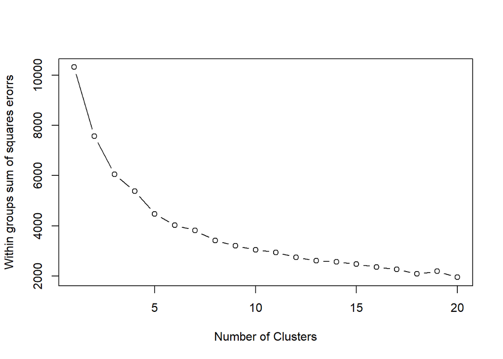

```r
regression <- read.csv("https://github.com/nlebovits/musa-500-hmwk-5/raw/main/data/RegressionData.csv")
data <- read.csv("https://github.com/nlebovits/musa-500-hmwk-5/raw/main/data/RegressionData.csv")
data <- data %>% select(-POLY_ID, -AREAKEY)
data <- scale(data)

data_see <- (nrow(data)-1)*sum(apply(data,2,var))

#nrow(data)-1
#apply(data,2,var)

kmeans(data, centers=2)
for (i in 2:20) data_see[i] <- sum(kmeans(data, centers=i)$withinss)

#data_see

plot(1:20, data_see, type="b", xlab="Number of Clusters",
     ylab="Within groups sum of squares erorrs")
```

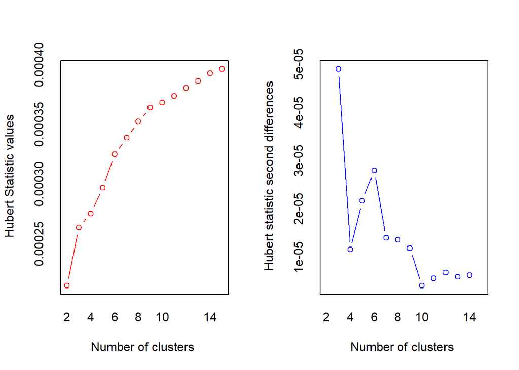

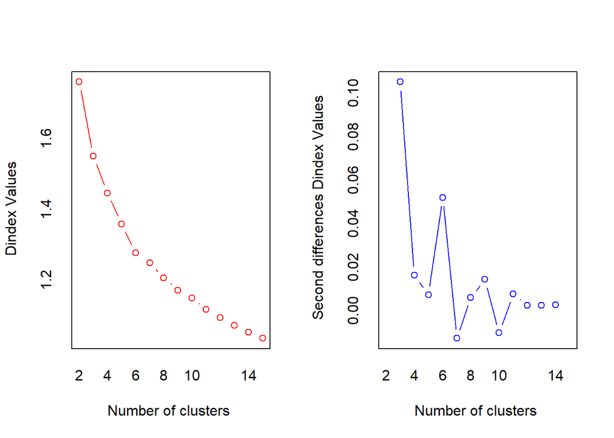

```r
set.seed(100)
nc <- NbClust(data, min.nc=2, max.nc=15, method="kmeans", index="all")
```

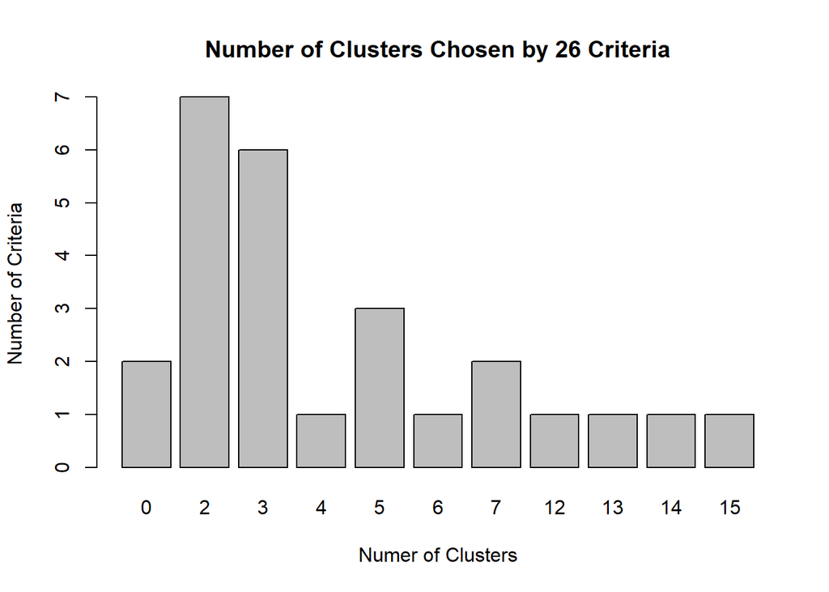

```r
#table(nc$Best.n[1,])

par(mfrow=c(1,1))
barplot(table(nc$Best.n[1,]),
        xlab="Numer of Clusters", ylab="Number of Criteria",
        main="Number of Clusters Chosen by 26 Criteria")
```

### **2. Three Clusters, Five Variables**

```r
set.seed(1234)
fit.km <- kmeans(data, 3, nstart=1000)

fit.km$size
round(fit.km$centers, 2)
fit.km$cluster

cluster_info = as.data.frame(fit.km$cluster)

table <- cbind(round(aggregate(data, by=list(cluster=fit.km$cluster), mean),1),fit.km$size)

colnames(table)[1] = c("CLUSTER")
colnames(table)[8] = c("SIZE")
```

```r
table <- table[, c(1, 8, 2, 3, 4, 5, 6, 7)]

table %>%
  kbl() %>%
  kable_paper("hover", full_width = F)
```

| CLUSTER | SIZE | MEDHVAL | PCTBACHMOR | MEDHHINC | PCTVACANT | PCTSINGLES | NBELPOV100 |
| --- | --- | --- | --- | --- | --- | --- | --- |
| 1 | 651 | -0.5 | -0.5 | -0.7 | 0.8 | -0.2 | 0.7 |
| 2 | 159 | 2.0 | 2.2 | 1.6 | -0.7 | 1.5 | -0.6 |
| 3 | 910 | 0.0 | 0.0 | 0.2 | -0.5 | -0.1 | -0.4 |

- Group 1: Lower Income
- Group 2: Bougie Community
- Group 3: Middle Class

### **3. Spatial Distribution of Clusters**

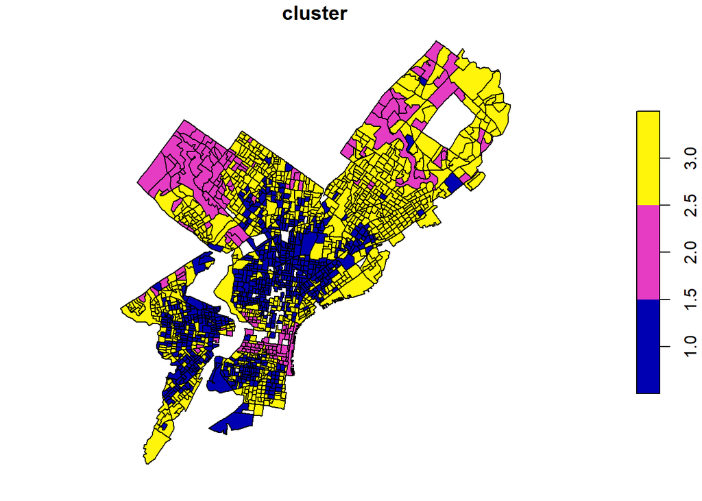

```r
Regression_cluster <- cbind(regression, cluster_info)

regression_shp <- st_read('C:/Users/Nissim/Desktop/Fall 2022/Spat Stats/Homeworks/ass_1_data_shp/RegressionData.shp')

#regression_shp <- st_read("/Users/annzhang/Downloads/HW 5/RegressionData.shp")

regression_shp <- left_join(regression_shp, Regression_cluster, by = "POLY_ID") %>% st_as_sf()

regression_cluster <- regression_shp %>% mutate(cluster = fit.km$cluster) %>% dplyr::select(cluster)

plot(regression_cluster)
```

By plotting the three groups on a map (as shown above), we can see some spatial autocorrelation. There seems to be spatial clustering of Group 2 (higher income, more educated communities) in some parts of Center City, the northwestern part of the city, and some parts of the northeast, and clustering of Group 1 (lower income) in the area north to the center city and some parts of West Philly. Since the clustering areas are not concentrated, it is difficult to rename the clusters by geographic locations.